# GeoPandas og PostGIS

Referanser som gir bakgunn for å forstå eksemplene nedenfor:

### Utvalgte referanser

- [geopandas.GeoDataFrame.to_postgis](https://geopandas.org/docs/reference/api/geopandas.GeoDataFrame.to_postgis.html#geopandas-geodataframe-to-postgis)
- [geopandas.read_postgis](https://geopandas.org/docs/reference/api/geopandas.read_postgis.html#geopandas-read-postgis)
- [pandas.read_sql](https://pandas.pydata.org/pandas-docs/stable/reference/api/pandas.read_sql.html#pandas-read-sql)
- [geopandas.GeoSeries.contains](https://geopandas.org/docs/reference/api/geopandas.GeoSeries.contains.html#geopandas-geoseries-contains)
- [PostGIS: ST_Contains](https://postgis.net/docs/manual-3.1/ST_Contains.html)
- [How do I select a subset of a DataFrame](https://pandas.pydata.org/pandas-docs/stable/getting_started/intro_tutorials/03_subset_data.html)
- [How do I filter specific rows from a DataFrame?](https://pandas.pydata.org/pandas-docs/stable/getting_started/intro_tutorials/03_subset_data.html#how-do-i-filter-specific-rows-from-a-dataframe)
- [How do I select specific columns from a DataFrame?](https://pandas.pydata.org/pandas-docs/stable/getting_started/intro_tutorials/03_subset_data.html#how-do-i-select-specific-columns-from-a-dataframe)

### GeoPandas generelle referanser

- [GeoSeries](https://geopandas.org/docs/reference/geoseries.html)
- [GeoDataFrame](https://geopandas.org/docs/reference/geodataframe.html)
- [Input/Output](https://geopandas.org/docs/reference/io.html)
- [Tools - inkludert Spatial Join](https://geopandas.org/docs/reference/tools.html)
- [API Reference](https://geopandas.org/docs/reference.html)

### PostGIS generelle referanser

- [3.3. Creating spatial databases](https://postgis.net/docs/manual-3.1/postgis_administration.html#create_spatial_db)
- [Chapter 4. PostGIS Usage](https://postgis.net/docs/manual-3.1/postgis_usage.html#eval_spatial_rel)
- [4.2. Spatial Queries](https://postgis.net/docs/manual-3.1/postgis_usage.html#using_postgis_query)
- [Chapter 5. PostGIS Reference](https://postgis.net/docs/manual-3.1/reference.html)
- [PostGIS hovedside](https://postgis.net/)
- [Workshop: Introduction to PostGIS](https://postgis.net/workshops/postgis-intro/)

```
NTNU 05.03.2021 - Sverre Stikbakke
```

## GeoDataFrame: teiger

```python
import pandas as pd
import geopandas as gpd
import fiona as fi
from shapely.geometry import Polygon, Point
```

```python
# Python dictionary (en innebygd datastruktur i Python)

data = {'smaragd': {
    'localid': 446124344,
    'objtype': 'Teig',
    'SHAPE_Length': 306.207095792018,
    'SHAPE_Area': 5747.21023925478,
    'geometry': Polygon([
        [591518.2, 6740464.0499],
        [591442.74, 6740401.1999],
        [591399.69, 6740452.8699],
        [591460.55, 6740518.9299],
        [591464.35, 6740525.3999],
        [591471.27, 6740517.5099],
        [591516.35, 6740466.1499],
        [591518.2, 6740464.0499],
        ]),
    }, 'beryll': {
    'localid': 49174530,
    'objtype': 'Teig',
    'SHAPE_Length': 306.207095792018,
    'SHAPE_Area': 5747.21023925478,
    'geometry': Polygon([
        [591535.31, 6740542.8499],
        [591546.79, 6740525.9499],
        [591565.3179, 6740498.2083],
        [591527.4193, 6740467.2872],
        [591516.35, 6740466.1499],
        [591471.27, 6740517.5099],
        [591464.35, 6740525.3999],
        [591494.5, 6740576.6499],
        [591514.4, 6740554.4999],
        [591525.4, 6740550.7899],
        [591535.31, 6740542.8499],
        ]),
    }}
```

```python
teiger = gpd.GeoDataFrame.from_dict(data, orient='index')
teiger.set_crs('EPSG:25832')
```

|  | localid | objtype | SHAPE_Length | SHAPE_Area | geometry |
| --- | --- | --- | --- | --- | --- |
| smaragd | 446124344 | Teig | 306.207096 | 5747.210239 | POLYGON ((591518.200 6740464.050, 591442.740 6... |
| beryll | 49174530 | Teig | 306.207096 | 5747.210239 | POLYGON ((591535.310 6740542.850, 591546.790 6... |

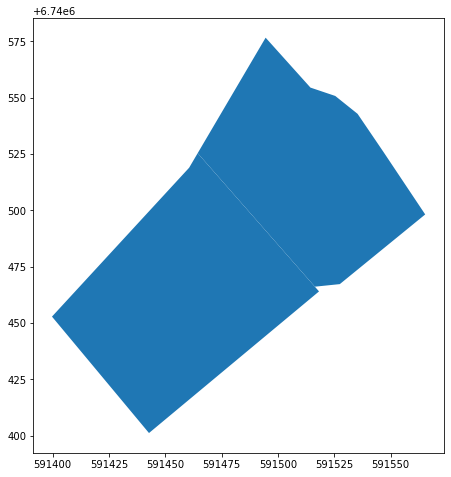

```python
teiger.plot(figsize=(8,8))
```

## GeoDataFrame: bygninger

```python
# skjuler warnings i cellen nedenfor
import warnings
warnings.filterwarnings('ignore')
```

```python
# fila som importeres her har Geopackage-format. Den er eksportert fra QGIS.
bygninger = gpd.read_file('bygninger_ved_ntnu.gpkg')
```

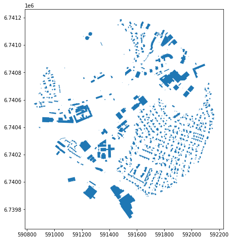

```python
bygninger.plot(figsize=(8,8))
```

## Postgis

Postgis-operasjoner med bruk av sqlalcemy, geoalchemy2 og psycopg2. Se *[Installasjon og oppstart av Geopandas i Windows 10](https://folk.ntnu.no/sverrsti/geopandas/installasjon.html)* for info om installasjon av nødvendige Python-pakker.

Brukernavn og passord til databasen, samt vertsnavn (host), portnummer og databasenavn legges i en egen fil, `mypostgisdb.py`, slik:

```
postgis_connection_string = "postgresql://brukernavn:passord@host:5432/databasenavn"
```

```python
from sqlalchemy import create_engine
from mypostgisdb import postgis_connection_string

db = create_engine(postgis_connection_string)
```

```python
# Disse linjene laster opp teiger og bygninger (GeoDataFrames) til databasen og oppretter tabeller med angitte navn.
# teiger.to_postgis('teiger', db)
# bygninger.to_postgis('bygninger', db)
```

## SQL-spørringer som ikke returnerer geometri: bruk `pd.read_sql()`

Enkle SQL-spørringer mot databasen gjøres med Pandas-funksjonen `read_sql()`. Spørringene vil returnere en Pandas DataFrame.

```python
sql = 'SELECT * from teiger'
pandas_df_teiger = pd.read_sql(sql, db)
pandas_df_teiger
```

|  | localid | objtype | SHAPE_Length | SHAPE_Area | geometry |
| --- | --- | --- | --- | --- | --- |
| 0 | 446124344 | Teig | 306.207096 | 5747.210239 | 01030000000100000008000000666666663C0D2241C58F... |
| 1 | 49174530 | Teig | 306.207096 | 5747.210239 | 0103000000010000000B000000EC51B89E5E0D2241F8C2... |

```python
# Geometri-kolonnen ble med her, men datatypen for enkelt-objektene er _str_. Den kan ikke brukes videre til geometri-operasjoner.
type(pandas_df_teiger.loc[0,'geometry'])
```

```
str
```

Vi kan bruke PostGIS-funksjoner i databasen med Pandas `read_sql()` dersom de ikke returnerer geometri-data:

```python
sql = 'SELECT localid, ST_Area(geometry) FROM teiger'
pandas_df_area = pd.read_sql(sql, db)
pandas_df_area
```

|  | localid | st_area |
| --- | --- | --- |
| 0 | 446124344 | 7166.961750 |
| 1 | 49174530 | 5747.210239 |

## SQL-spørringer som returnerer geometri: bruk `gpd.read_postgis()`

GeoPandas-funksjonen `read_postgis()` krever at SQL-spørringen skal returnere en geometri-kolonne.  
Det vil si at SELECT-delen av SQL-spørringen må inkludere en geometri-kolonne, enten eksplisitt eller implisitt som i `SELECT *`.  
Merk også at kolonnenavn som inneholder store bokstaver må settes i anførselstegn.  
Dette fungerer:

```
sql = 'SELECT * FROM teiger'
```

Dette fungerer ikke - gir feilmelding:

```
sql = 'SELECT localid, "SHAPE_Length" FROM teiger'
```

Dette fungerer:

```
sql = 'SELECT localid, "SHAPE_Length", geometry FROM teiger'
```

```python
# Disse variablene brukes i spørringer med gpd.read_postgis()
geom_col = 'geometry'
crs = 'EPSG:25832'
```

```python
sql = 'SELECT * FROM teiger'
geopandas_df_teiger = gpd.read_postgis(sql, db, geom_col, crs)
geopandas_df_teiger
```

|  | localid | objtype | SHAPE_Length | SHAPE_Area | geometry |
| --- | --- | --- | --- | --- | --- |
| 0 | 446124344 | Teig | 306.207096 | 5747.210239 | POLYGON ((591518.200 6740464.050, 591442.740 6... |
| 1 | 49174530 | Teig | 306.207096 | 5747.210239 | POLYGON ((591535.310 6740542.850, 591546.790 6... |

```python
# Geometri-objektene har nå datatypen _shapely.geometry.polygon.Polygon_
type(geopandas_df_teiger.loc[0,'geometry'])
```

```
shapely.geometry.polygon.Polygon
```

```python
sql = 'SELECT localid, "SHAPE_Length", geometry FROM teiger'
geopandas_df_teiger_length = gpd.read_postgis(sql, db, geom_col, crs)
geopandas_df_teiger_length
```

|  | localid | SHAPE_Length | geometry |
| --- | --- | --- | --- |
| 0 | 446124344 | 306.207096 | POLYGON ((591518.200 6740464.050, 591442.740 6... |
| 1 | 49174530 | 306.207096 | POLYGON ((591535.310 6740542.850, 591546.790 6... |

## Sammenligning: Egenhofer-topologi-spørring med PostGIS-funksjoner vs. GeoPandas-funksjoner

Med spørringen vil vi finne de bygningene som ligger innenfor teig-polygonene for Beryll- og Smaragd-byggene.

- PostGIS-varianten forutsetter at dataene er lastet opp til tabeller i en PostGIS-database.
- PostGIS-spørringen returnerer en komplett GeoDataFrame med de kolonnene som er spesifiert i spørringen.
- GeoPandas-varianten returnerer en Pandas Series med True- eller False-verdier. Denne legges direkte inn i en eksisterende GeoDataFrame for bygninger.
- Generell Pandas-funksjonalitet brukes for å hente ut radene med True-verdier, og kolonnene *objectid* og *geometry*.

Se [Egenhofer-topologi](https://folk.ntnu.no/sverrsti/geopandas/egenhofer.html) for nærmere beskrivelse av GeoPandas-varianten.

```python
sql = 'SELECT objectid, bygninger.geometry FROM bygninger, teiger WHERE ST_CONTAINS(teiger.geometry, bygninger.geometry)'
utvalg_bygninger_postgis = gpd.read_postgis(sql, db, geom_col, crs)
utvalg_bygninger_postgis
```

|  | objectid | geometry |
| --- | --- | --- |
| 0 | 3140 | MULTIPOLYGON Z (((591464.400 6740433.940 184.9... |
| 1 | 29039 | MULTIPOLYGON Z (((591457.090 6740476.920 191.2... |
| 2 | 9906 | MULTIPOLYGON Z (((591482.390 6740523.390 198.8... |
| 3 | 34964 | MULTIPOLYGON Z (((591516.280 6740536.880 190.1... |

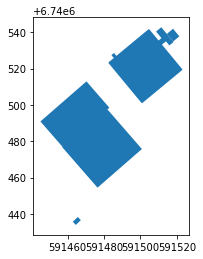

```python
utvalg_bygninger_postgis.plot()
```

```python
# oppdaterer Geopandas GeoDataFrame bygninger med en ny kolonne, Beryll_Smaragd, med True/False, som angir om bygningene ligger innenfor noen av teig-polygonene
bygninger['Beryll_Smaragd'] = bygninger.geometry.apply(lambda bygning: teiger.geometry.contains(bygning).any())
utvalg_bygninger_geopandas = bygninger[bygninger.Beryll_Smaragd == True][["objectid", "geometry"]]
utvalg_bygninger_geopandas
```

|  | objectid | geometry |
| --- | --- | --- |
| 91 | 3140 | MULTIPOLYGON Z (((591464.400 6740433.940 184.9... |
| 283 | 9906 | MULTIPOLYGON Z (((591482.390 6740523.390 198.8... |
| 834 | 29039 | MULTIPOLYGON Z (((591457.090 6740476.920 191.2... |
| 1048 | 34964 | MULTIPOLYGON Z (((591516.280 6740536.880 190.1... |

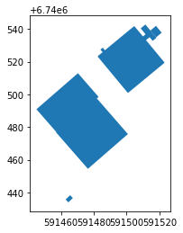

```python
utvalg_bygninger_geopandas.plot()
```

```python
utvalg_bygninger_geopandas.loc[91][['geometry']]
```

```
geometry    (POLYGON Z ((591464.3997999998 6740433.9399 18...
Name: 91, dtype: object
```